In this project, we want to predict whether an individual is performing barbell lifts properly or not.

Load the packages ggplot2 and caret and read both the training and testing sets. Get a summary of the data

```r
library(ggplot2)
library(caret)
training_data <- read.table("pml-training.csv", header = TRUE, sep = ",")
testing_data <- read.table("pml-testing.csv", header = TRUE, sep = ",")
table(training_data$classe)
```

```
##
##    A    B    C    D    E
## 5580 3797 3422 3216 3607
```

The summary of the training data indicates that 6 individuals completed one set of 10 repetitions of the Unilateral Dumbbell Biceps Curl in five different fashions:

- Class A: Exactly according to the specification
- Class B: Throwing the elbows to the front
- Class C: Lifting the dumbbell only halfway
- Class D: Lowering the dumbbell only halfway
- Class E: Throwing the hips to the front. The recording of such measurements were stored in a data frame consisting of 19622 observations and for each observation, 160 pieces of information were recorded, some of them missing or recorded as NA. Define a new data frame retaining columns that are not mostly NA or have meaningful values. Information about time stamp and window have been eliminated as they do not contribute to model development

```r
training_data_0 <- cbind(training_data$roll_belt, training_data$pitch_belt, training_data$yaw_belt, training_data$total_accel_belt)
testing_data_0 <- cbind(testing_data$roll_belt, testing_data$pitch_belt, testing_data$yaw_belt, testing_data$total_accel_belt)
training_data_0 <- cbind(training_data_0, training_data$gyros_belt_x, training_data$gyros_belt_y, training_data$gyros_belt_z, training_data$accel_belt_x, training_data$accel_belt_y, training_data$accel_belt_z, training_data$magnet_belt_x, training_data$magnet_belt_y, training_data$magnet_belt_z)
testing_data_0 <- cbind(testing_data_0, testing_data$gyros_belt_x, testing_data$gyros_belt_y, testing_data$gyros_belt_z, testing_data$accel_belt_x, testing_data$accel_belt_y, testing_data$accel_belt_z, testing_data$magnet_belt_x, testing_data$magnet_belt_y, testing_data$magnet_belt_z)
training_data_0 <- cbind(training_data_0,training_data$roll_arm, training_data$pitch_arm, training_data$yaw_arm, training_data$total_accel_arm)
testing_data_0 <- cbind(testing_data_0, testing_data$roll_arm, testing_data$pitch_arm, testing_data$yaw_arm, testing_data$total_accel_arm)
training_data_0 <- cbind(training_data_0, training_data$gyros_arm_x, training_data$gyros_arm_y, training_data$gyros_arm_z, training_data$accel_arm_x, training_data$accel_arm_y, training_data$accel_arm_z, training_data$magnet_arm_x, training_data$magnet_arm_y, training_data$magnet_arm_z)
testing_data_0 <- cbind(testing_data_0, testing_data$gyros_arm_x, testing_data$gyros_arm_y, testing_data$gyros_arm_z, testing_data$accel_arm_x, testing_data$accel_arm_y, testing_data$accel_arm_z, testing_data$magnet_arm_x, testing_data$magnet_arm_y, testing_data$magnet_arm_z)
training_data_0 <- cbind(training_data_0,training_data$roll_dumbbell, training_data$pitch_dumbbell, training_data$yaw_dumbbell, training_data$total_accel_dumbbell)
testing_data_0 <- cbind(testing_data_0, testing_data$roll_dumbbell, testing_data$pitch_dumbbell, testing_data$yaw_dumbbell, testing_data$total_accel_dumbbell)
training_data_0 <- cbind(training_data_0, training_data$gyros_dumbbell_x, training_data$gyros_dumbbell_y, training_data$gyros_dumbbell_z, training_data$accel_dumbbell_x, training_data$accel_dumbbell_y, training_data$accel_dumbbell_z, training_data$magnet_dumbbell_x, training_data$magnet_dumbbell_y, training_data$magnet_dumbbell_z)
testing_data_0 <- cbind(testing_data_0, testing_data$gyros_dumbbell_x, testing_data$gyros_dumbbell_y, testing_data$gyros_dumbbell_z, testing_data$accel_dumbbell_x, testing_data$accel_dumbbell_y, testing_data$accel_dumbbell_z, testing_data$magnet_dumbbell_x, testing_data$magnet_dumbbell_y, testing_data$magnet_dumbbell_z)
training_data_0 <- cbind(training_data_0,training_data$roll_forearm, training_data$pitch_forearm, training_data$yaw_forearm, training_data$total_accel_forearm)
testing_data_0 <- cbind(testing_data_0, testing_data$roll_forearm, testing_data$pitch_forearm, testing_data$yaw_forearm, testing_data$total_accel_forearm)
training_data_0 <- cbind(training_data_0, training_data$gyros_forearm_x, training_data$gyros_forearm_y, training_data$gyros_forearm_z, training_data$accel_forearm_x, training_data$accel_forearm_y, training_data$accel_forearm_z, training_data$magnet_forearm_x, training_data$magnet_forearm_y, training_data$magnet_forearm_z)
testing_data_0 <- cbind(testing_data_0, testing_data$gyros_forearm_x, testing_data$gyros_forearm_y, testing_data$gyros_forearm_z, testing_data$accel_forearm_x, testing_data$accel_forearm_y, testing_data$accel_forearm_z, testing_data$magnet_forearm_x, testing_data$magnet_forearm_y, testing_data$magnet_forearm_z)
vector_training_names <- c("roll_belt", "pitch_belt", "yaw_belt", "total_accel_belt", "gyros_belt_x", "gyros_belt_y", "gyros_belt_z", "accel_belt_x", "accel_belt_y", "accel_belt_z", "magnet_belt_x", "magnet_belt_y", "magnet_belt_z", "roll_arm", "pitch_arm", "yaw_arm", "total_accel_arm", "gyros_arm_x", "gyros_arm_y", "gyros_arm_z", "accel_arm_x", "accel_arm_y", "accel_arm_z", "magnet_arm_x", "magnet_arm_y", "magnet_arm_z", "roll_dumbbell", "pitch_dumbbell", "yaw_dumbbell", "total_accel_dumbbell", "gyros_dumbbell_x", "gyros_dumbbell_y", "gyros_dumbbell_z", "accel_dumbbell_x", "accel_dumbbell_y", "accel_dumbbell_z", "magnet_dumbbell_x", "magnet_dumbbell_y", "magnet_dumbbell_z", "roll_forearm", "pitch_forearm", "yaw_forearm", "total_accel_forearm", "gyros_forearm_x", "gyros_forearm_y", "gyros_forearm_z", "accel_forearm_x", "accel_forearm_y", "accel_forearm_z", "magnet_forearm_x", "magnet_forearm_y", "magnet_forearm_z")
colnames(training_data_0) <- vector_training_names
colnames(testing_data_0) <- vector_training_names
```

The transformed training data frame has now 19622 rows and 52 columns, the recordings being the roll, pitch, yaw, total acceleration of belt, arm, dumbbell, and forearm. It also records gyros, accelaration, magnet in each of the three dimensions for the belt, arm, dumbbell, and forearm, as well as the class.

We first graph the scatter plot matrix of the roll, pitch, yaw, and total acceleration for the belt.

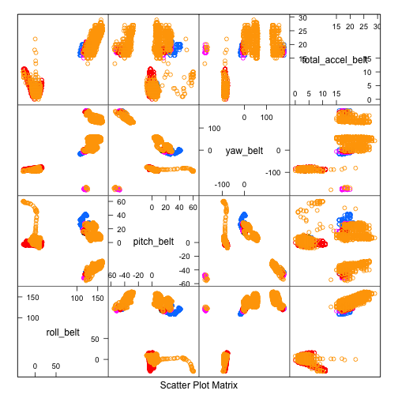

```r
featurePlot(x = training_data_0[, c("roll_belt", "pitch_belt", "yaw_belt", "total_accel_belt")], y = as.factor(training_data$classe), plot="pairs")
```

From the Scatter Plot Matrix, we see that the belt is not very effective at identifying whether the activity was properly completed since the ScatterPlot Matrix does not separate the different classes. Plotting similar Scatter Plot Matrices involving only the arm, dumbbell, or forearm do not provide better information on whether the activity was properly conducted. Therefore, all the different types of measurements should be incorporated in the model.

Using the caret package and the train function we develop a classification random forest model with cross-validation 10 fold, no preprocessing, using as data the data frame training_data_0 and the field training_data$classe indicating how the individual performed the exercise. The data frame training_data_0 has been derived by eliminating from the provided training data the mostly NA fields.

```r
rfrepeatedCVModel <- train(training_data_0, as.factor(training_data$classe), method = "rf", scale = FALSE, trControl = trainControl(method = "repeatedcv", number = 10))
rfrepeatedCVModelfinal <- rfrepeatedCVModel$finalModel
print(rfrepeatedCVModelfinal)
```

```
##
## Call:
##  randomForest(x = x, y = y, mtry = param$mtry, scale = FALSE)
##                Type of random forest: classification
##                      Number of trees: 500
## No. of variables tried at each split: 2
##
##         OOB estimate of  error rate: 0.44%
## Confusion matrix:
##      A    B    C    D    E class.error
## A 5579    1    0    0    0   0.0001792
## B    9 3784    4    0    0   0.0034238
## C    0   19 3401    2    0   0.0061368
## D    0    0   45 3170    1   0.0143035
## E    0    0    0    6 3601   0.0016634
```

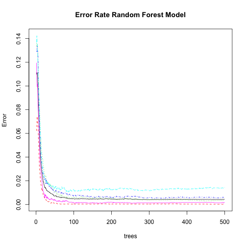

```r
plot(rfrepeatedCVModelfinal, main = "Error Rate Random Forest Model")
```

From the graph of the error rate, we see that once you have 200 trees, the error rate does not improve significantly

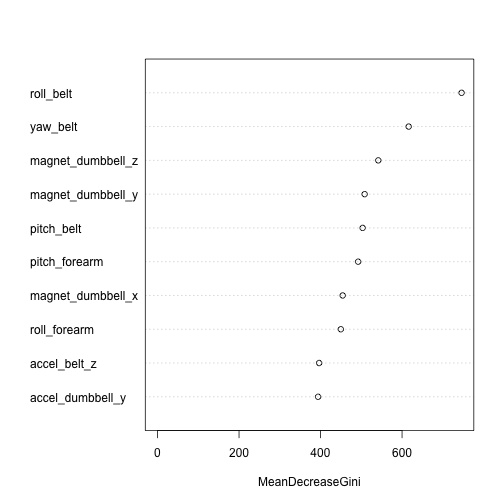

```r
varImpPlot(rfrepeatedCVModelfinal, sort = TRUE, n.var = 10, main = "", scale = TRUE)
```

```r
importance(rfrepeatedCVModelfinal, type=2)
```

```
##                      MeanDecreaseGini
## roll_belt                       746.1
## pitch_belt                      503.3
## yaw_belt                        616.3
## total_accel_belt                260.2
## gyros_belt_x                    171.6
## gyros_belt_y                    175.9
## gyros_belt_z                    289.5
## accel_belt_x                    202.8
## accel_belt_y                    191.2
## accel_belt_z                    396.5
## magnet_belt_x                   267.5
## magnet_belt_y                   375.7
## magnet_belt_z                   385.9
## roll_arm                        326.1
## pitch_arm                       235.4
## yaw_arm                         260.2
## total_accel_arm                 171.9
## gyros_arm_x                     207.4
## gyros_arm_y                     207.2
## gyros_arm_z                     120.9
## accel_arm_x                     279.9
## accel_arm_y                     219.4
## accel_arm_z                     202.9
## magnet_arm_x                    293.4
## magnet_arm_y                    279.8
## magnet_arm_z                    234.3
## roll_dumbbell                   385.9
## pitch_dumbbell                  253.0
## yaw_dumbbell                    306.7
## total_accel_dumbbell            298.5
## gyros_dumbbell_x                188.1
## gyros_dumbbell_y                291.4
## gyros_dumbbell_z                140.3
## accel_dumbbell_x                307.1
## accel_dumbbell_y                394.0
## accel_dumbbell_z                352.6
## magnet_dumbbell_x               454.3
## magnet_dumbbell_y               508.2
## magnet_dumbbell_z               541.7
## roll_forearm                    449.8
## pitch_forearm                   492.2
## yaw_forearm                     225.1
## total_accel_forearm             177.0
## gyros_forearm_x                 141.0
## gyros_forearm_y                 191.2
## gyros_forearm_z                 145.8
## accel_forearm_x                 322.7
## accel_forearm_y                 219.7
## accel_forearm_z                 257.5
## magnet_forearm_x                272.4
## magnet_forearm_y                264.9
## magnet_forearm_z                284.5
```

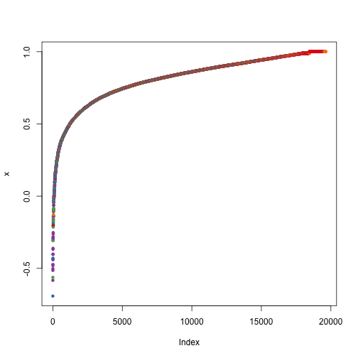

```r
plot(margin(rfrepeatedCVModelfinal))
```

The plot of margin confirms a very low error rate since very few points out of the training data have a negative margin.

```r
rfrepeatedCVModelpred_training_data_0 <- predict(rfrepeatedCVModelfinal, type="response")
confusionMatrix(rfrepeatedCVModelpred_training_data_0, as.factor(training_data$classe))
```

```
## Confusion Matrix and Statistics
##
##           Reference
## Prediction    A    B    C    D    E
##          A 5579    9    0    0    0
##          B    1 3784   19    0    0
##          C    0    4 3401   45    0
##          D    0    0    2 3170    6
##          E    0    0    0    1 3601
##
## Overall Statistics
##
##                Accuracy : 0.996
##                  95% CI : (0.995, 0.996)
##     No Information Rate : 0.284
##     P-Value [Acc > NIR] : <2e-16
##
##                   Kappa : 0.994
##  Mcnemar's Test P-Value : NA
##
## Statistics by Class:
##
##                      Class: A Class: B Class: C Class: D Class: E
## Sensitivity             1.000    0.997    0.994    0.986    0.998
## Specificity             0.999    0.999    0.997    1.000    1.000
## Pos Pred Value          0.998    0.995    0.986    0.997    1.000
## Neg Pred Value          1.000    0.999    0.999    0.997    1.000
## Prevalence              0.284    0.194    0.174    0.164    0.184
## Detection Rate          0.284    0.193    0.173    0.162    0.184
## Detection Prevalence    0.285    0.194    0.176    0.162    0.184
## Balanced Accuracy       1.000    0.998    0.995    0.993    0.999
```

The developed model has a relative low error rate on the training data, less than half a percent, and a Kappa value of more than .99; both the specificity and sentivity are more than 98%; the activity exactly according to the specifics has the lowest error rate, highest sensitivity while lowering the dumbbell only halfway has highest error rate and lowest sensitivity. The P-value of accuracy greater than No Information rate is less than 2e-16. The balance accuracy is greater than 99.3% for all the outcomes. The confusion matrix is a nearly banded matrix which indicates that, even though the predictions are not 100% accurate, the discrepancies are not major.

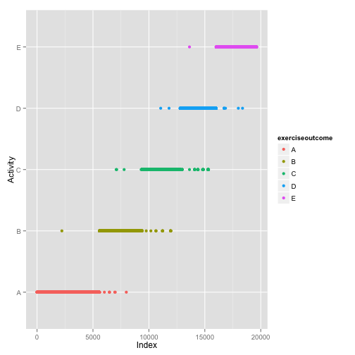

```r
exerciseoutcome <- rfrepeatedCVModelpred_training_data_0
qplot(seq_along(rfrepeatedCVModelpred_training_data_0), rfrepeatedCVModelpred_training_data_0, colour = exerciseoutcome, xlab = "Index", ylab = "Activity")
```

The above plot provides the predicted values for the developed model using the training set. Only a few points differs when comparing to the original labels.

```r
rfrepeatedCVModelpred_testing_data_case1 <- predict(rfrepeatedCVModelfinal, newdata = testing_data_0[1,], type="response")
rfrepeatedCVModelpred_testing_data_case2 <- predict(rfrepeatedCVModelfinal, newdata = testing_data_0[2,], type="response")
rfrepeatedCVModelpred_testing_data_case3 <- predict(rfrepeatedCVModelfinal, newdata = testing_data_0[3,], type="response")
rfrepeatedCVModelpred_testing_data_case4 <- predict(rfrepeatedCVModelfinal, newdata = testing_data_0[4,], type="response")
rfrepeatedCVModelpred_testing_data_case5 <- predict(rfrepeatedCVModelfinal, newdata = testing_data_0[5,], type="response")
rfrepeatedCVModelpred_testing_data_case6 <- predict(rfrepeatedCVModelfinal, newdata = testing_data_0[6,], type="response")
rfrepeatedCVModelpred_testing_data_case7 <- predict(rfrepeatedCVModelfinal, newdata = testing_data_0[7,], type="response")
rfrepeatedCVModelpred_testing_data_case8 <- predict(rfrepeatedCVModelfinal, newdata = testing_data_0[8,], type="response")
rfrepeatedCVModelpred_testing_data_case9 <- predict(rfrepeatedCVModelfinal, newdata = testing_data_0[9,], type="response")
rfrepeatedCVModelpred_testing_data_case10 <- predict(rfrepeatedCVModelfinal, newdata = testing_data_0[10,], type="response")
rfrepeatedCVModelpred_testing_data_case11 <- predict(rfrepeatedCVModelfinal, newdata = testing_data_0[11,], type="response")
rfrepeatedCVModelpred_testing_data_case12 <- predict(rfrepeatedCVModelfinal, newdata = testing_data_0[12,], type="response")
rfrepeatedCVModelpred_testing_data_case13 <- predict(rfrepeatedCVModelfinal, newdata = testing_data_0[13,], type="response")
rfrepeatedCVModelpred_testing_data_case14 <- predict(rfrepeatedCVModelfinal, newdata = testing_data_0[14,], type="response")
rfrepeatedCVModelpred_testing_data_case15 <- predict(rfrepeatedCVModelfinal, newdata = testing_data_0[15,], type="response")
rfrepeatedCVModelpred_testing_data_case16 <- predict(rfrepeatedCVModelfinal, newdata = testing_data_0[16,], type="response")
rfrepeatedCVModelpred_testing_data_case17 <- predict(rfrepeatedCVModelfinal, newdata = testing_data_0[17,], type="response")
rfrepeatedCVModelpred_testing_data_case18 <- predict(rfrepeatedCVModelfinal, newdata = testing_data_0[18,], type="response")
rfrepeatedCVModelpred_testing_data_case19 <- predict(rfrepeatedCVModelfinal, newdata = testing_data_0[19,], type="response")
rfrepeatedCVModelpred_testing_data_case20 <- predict(rfrepeatedCVModelfinal, newdata = testing_data_0[20,], type="response")
print(rfrepeatedCVModelpred_testing_data_case1)
```

```
## 1
## B
## Levels: A B C D E
```

```r
print(rfrepeatedCVModelpred_testing_data_case2)
```

```
## 1
## A
## Levels: A B C D E
```

```r
print(rfrepeatedCVModelpred_testing_data_case3)
```

```
## 1
## B
## Levels: A B C D E
```

```r
print(rfrepeatedCVModelpred_testing_data_case4)
```

```
## 1
## A
## Levels: A B C D E
```

```r
print(rfrepeatedCVModelpred_testing_data_case5)
```

```
## 1
## A
## Levels: A B C D E
```

```r
print(rfrepeatedCVModelpred_testing_data_case6)
```

```
## 1
## E
## Levels: A B C D E
```

```r
print(rfrepeatedCVModelpred_testing_data_case7)
```

```
## 1
## D
## Levels: A B C D E
```

```r
print(rfrepeatedCVModelpred_testing_data_case8)
```

```
## 1
## B
## Levels: A B C D E
```

```r
print(rfrepeatedCVModelpred_testing_data_case9)
```

```
## 1
## A
## Levels: A B C D E
```

```r
print(rfrepeatedCVModelpred_testing_data_case10)
```

```
## 1
## A
## Levels: A B C D E
```

```r
print(rfrepeatedCVModelpred_testing_data_case11)
```

```
## 1
## B
## Levels: A B C D E
```

```r
print(rfrepeatedCVModelpred_testing_data_case12)
```

```
## 1
## C
## Levels: A B C D E
```

```r
print(rfrepeatedCVModelpred_testing_data_case13)
```

```
## 1
## B
## Levels: A B C D E
```

```r
print(rfrepeatedCVModelpred_testing_data_case14)
```

```
## 1
## A
## Levels: A B C D E
```

```r
print(rfrepeatedCVModelpred_testing_data_case15)
```

```
## 1
## E
## Levels: A B C D E
```

```r
print(rfrepeatedCVModelpred_testing_data_case16)
```

```
## 1
## E
## Levels: A B C D E
```

```r
print(rfrepeatedCVModelpred_testing_data_case17)
```

```
## 1
## A
## Levels: A B C D E
```

```r
print(rfrepeatedCVModelpred_testing_data_case18)
```

```
## 1
## B
## Levels: A B C D E
```

```r
print(rfrepeatedCVModelpred_testing_data_case19)
```

```
## 1
## B
## Levels: A B C D E
```

```r
print(rfrepeatedCVModelpred_testing_data_case20)
```

```
## 1
## B
## Levels: A B C D E
```